# Relationship between Transmission Type and Motor Vehicle MPG Efficiency

Felix E. Rivera-Mariani, PhD

February 2, 2016

### Summary

This report evaluates the relationship of transmission type (i.e. automatic or manual) on motor vehicle miles per gallon (MPG) efficiency. The dataset **mtcars** from the R Package **Datasets** was evaluated in this report. Exploratory analysis provided evidence to suggest that there is difference in MPG between automatic and manual transmissions. An unpaired t.test was performed, which rejected the null hypothesis (*p* = 0.001) that the mean MPG between automatic and manual transmissions were equal with a mean MPG difference of 7. After performing a simple linear regression, type of transmissions accounted for 34% in the MPG variability. With multivariate linear regression and An Information Criterion (AIC) stepwise algorithm, it was found that 84% of the MPG variability is explained when transmission type is confounded with, cylinders, horse power, and weight of the car: manual transmission yield a 1.8 MPG increase compared to automatic transmission. From this data analysis, we conclude that transmission type does influence MPG, but this effect is further influence by other motor vehicle variables such as the number of cylinders, horse power, and weight.

### Data Analysis Code

The complete code for this data analysis is available [here](https://github.com/friveramariani/regression-models-prjt1)

### Variables in the dataset

1. mpg: miles per gallon (numerical)
2. cyl: number of cylinders (factor, 4,6,8)
3. disp: displacement (cu.in.) (numerical)
4. hp: gross horsepower (numerical)
5. drat: rear axle ratio (numerical)
6. wt: weight (1000 pounds) (numerical)
7. qsec: 1/4 mile time (numerical)
8. vs: V/S, V-engine or Straight engine (factor, V,S)
9. am: transmission type (factor, automatic, manual)
10. gear: number of forwards gears (factor, 3,4,5)
11. carb: number of carburetors (factor, 1,2,3,4,5,6,7,8)

### Loading and Processing the Dataset

```r
data(mtcars)
```

```r
str(mtcars)
```

[output not shown]

After examining the dimensions of the datasets and the classes of the variables, cyl, vs, am, gear, and carb do not have continuous observations. These variables were then transformed into factor variables.

```r
library (dplyr)
mtcars <- rename (mtcars, transm = am)
##am renamed to transm to better reflect that this columns corresponds to transmissions type

mtcars$transm <- factor(mtcars$transm,labels=c("Automatic","Manual"))
##the two levels in the transmission column were re-labeled (0 = Automatic, 1 = Manual)

mtcars$cyl <- factor(mtcars$cyl,labels=c("4cyl","6cyl","8cyl"))
##the three levels in cyl re-labeled (4 = 4cyl, 6 = 6cyl, 8 = 8cyl)

mtcars$vs <- factor(mtcars$vs)
mtcars$gear <- factor(mtcars$gear,levels=c(3,4,5), labels=c("3gears","4gears","5gears"))
##the three levels in gear were re-labeled (3 = 3gears, 4 = gears, 5 = 5gears)

mtcars$carb <- factor(mtcars$carb)
```

### Exploratory analysis

A boxplot was constructed to compare the distribution of MPG by Transmission Type

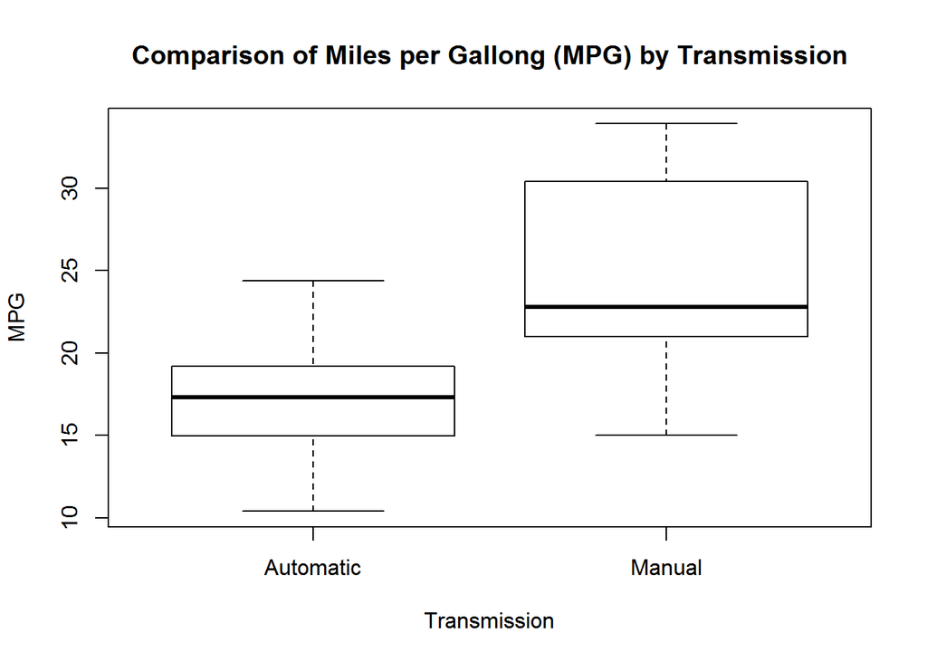

From the boxplot above, the median, 25th and 75th quantiles of MPG are higher for manual transmission.

### Inferential analysis

To evaluate that the means of automatic and manual transmission are not equal, an unpaired t.test was performed.

```
##
##  Welch Two Sample t-test
##
## data:  mpg by transm
## t = -3.7671, df = 18.332, p-value = 0.001374
## alternative hypothesis: true difference in means is not equal to 0
## 95 percent confidence interval:
##  -11.280194  -3.209684
## sample estimates:
## mean in group Automatic    mean in group Manual
##                17.14737                24.39231
```

From the results of the two-sample t test, we reject (*p* = 0.001) the null hypothesis that the means of automatic and manual transmissions are equal In addition, there is a mean difference of 7 MPG from manual to automatic transmission.

### Strategy for Model Selection

Because the initial question to answer was *if there is a difference in MPG by type of transmission*, an simple linear regression was performed with mpg as outcome and transmission as predictor.

```r
fit <- lm (mpg ~ transm, mtcars)
library(pander)
pander(summary(fit))
```

|  | Estimate | Std. Error | t value | Pr(>\|t\|) |
| --- | --- | --- | --- | --- |
| **transmManual** | 7.245 | 1.764 | 4.106 | 0.000285 |
| **(Intercept)** | 17.15 | 1.125 | 15.25 | 1.134e-15 |

Fitting linear model: mpg ~ transm From this simple regression model with a *p* < 0.001, **manual transmissions yields 7.3 MPG higher than automatic** transmission. Nevertheless, the **models explains only 34%** of the regression variance for MPG (adjusted R-squared = 0.3384). This results suggests that other variables influence the MPG variability besides transmission type. As seen in the **paired graph (refer to the Appendix)**, there are other variables that seem to influence MPG variability.

| Observations | Residual Std. Error | $R^2$ | Adjusted $R^2$ |
| --- | --- | --- | --- |
| 32 | 4.902 | 0.3598 | 0.3385 |

To further evaluate the idea that other variables in addition to transmission type influence MPG, a **An Information Criterion with an Backward Stepwise Algorithm** was performed. The initial model to perform this algorithm was MPG as outcome, and all predictors in the mtcars dataset.

```r
full.fit <- lm(mpg ~., mtcars)
best.fit <- step(full.fit, direction = "backward")
##results were hidden to limit the report's page length
```

|  | Estimate | Std. Error | t value | Pr(>\|t\|) |
| --- | --- | --- | --- | --- |
| **cyl6cyl** | -3.031 | 1.407 | -2.154 | 0.04068 |
| **cyl8cyl** | -2.164 | 2.284 | -0.9472 | 0.3523 |
| **hp** | -0.03211 | 0.01369 | -2.345 | 0.02693 |
| **wt** | -2.497 | 0.8856 | -2.819 | 0.009081 |
| **transmManual** | 1.809 | 1.396 | 1.296 | 0.2065 |
| **(Intercept)** | 33.71 | 2.605 | 12.94 | 7.733e-13 |

Fitting linear model: mpg ~ cyl + hp + wt + transm From the AIC-selected model, cylinder (*p* = 0.04 for 6 cylinders), horse power (*p* = 0.03), and weight (*p* < 0.01) influence MPG. These results suggest that within this data set, cylinders, horse power, and weight of the cars confound the effect of transmission type on MPG. As reported by the adjusted R-squared, this models explains 84% of the regression variance.

| Observations | Residual Std. Error | $R^2$ | Adjusted $R^2$ |
| --- | --- | --- | --- |
| 32 | 2.41 | 0.8659 | 0.8401 |

Finally, plots were constructed to evaluate patterns and non-normality of residuals.

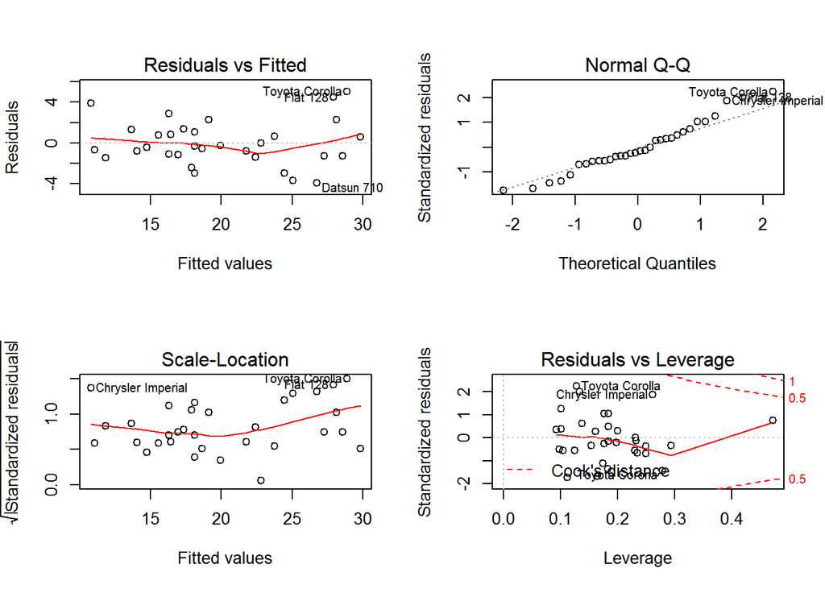

From the **Residuals vs Fitted** graph, the residuals do not show heteroskedacity as the variance seems to be similar throughout the plot. In addition, from the **quantile plot**, the residuals demonstrate a normal distribution.

### Appendix

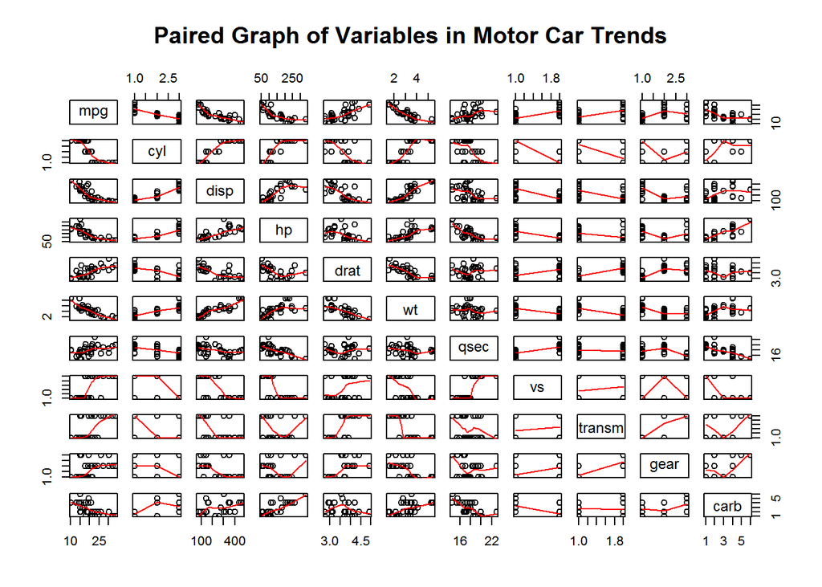